# The Great American Coffee Taste Test

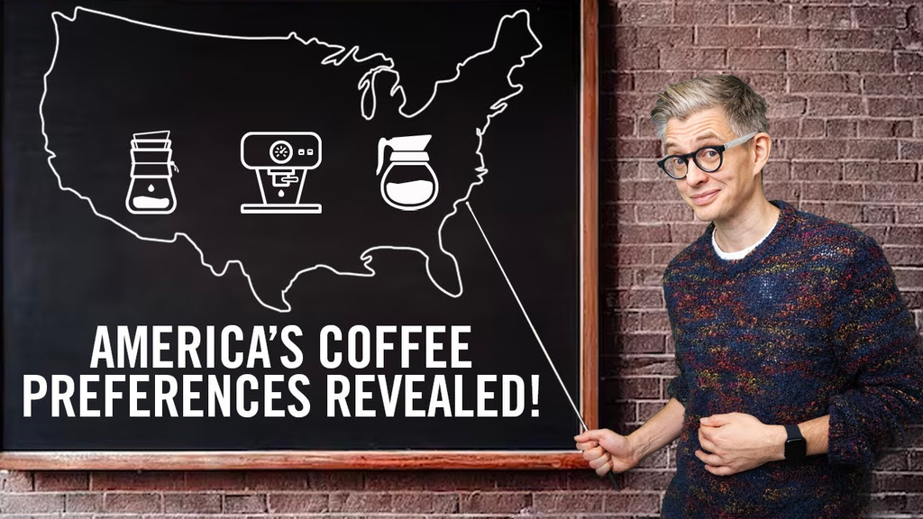

In 2023 James Hoffman surveyed 4000 US residents to understand how they enjoyed coffees A, B, C and D. He also asked some questions about their coffee consumption habits and some basic demographic data.

Watch James discuss his survey and the results [here](https://youtu.be/bMOOQfeloH0?si=da3OMVy5L4jQ5pXx). You can download the .csv of responses [here](https://bit.ly/gacttCSV).

#### The Coffees

Coffees A (light), B (medium), and C (dark) were all washed coffees but differed by roast level. Coffee D was a naturally processed single estate coffee from Colombia with more fruity, fermented flavours.

Coffees B and C are what many people would consider "normal" coffee, darker roast flavours of chocolate and nuts. Coffee A was a light roasted Kenyan coffee with fruitier, more acidic flavours that are increasingly popular in the 21st century.

Coffee D may be a totally new experience for some people because of the high level of fermentation and unusual variety.

All the coffees were delivered as frozen extracts delivered by [Cometeer](https://cometeer.com/pages/how-it-works), designed to be melted in hot water by respondents. This way everyone gets a near identical experience because the participants are not brewing the coffee themselves.

**My primary goal in this analysis is to answer 2 questions:**

- What is this coffee like?
  - How does it taste? How much do people like it?
- How does preference differ among different consumers?
  - Can we identify a coffee everyone likes?

#### Contents

- 1. What's this coffee like?
- 2. Respondents
- 3. Gender
- 4. Age
- 5. Ethnicity
- 6. Favourite type of drink
- 7. Spenders
- 8. Experts?
- Conclusions

## 1. What's this coffee like?

In this section we explore the tasting notes, the balance of acidity-bitterness. Then ask: which coffee is the most popular?

Back to the top

### Tasting notes

All the respondents were asked to describe the tasting notes of the coffees in their own words. Here I use word clouds to give a sense of the most common attributes of each coffee.

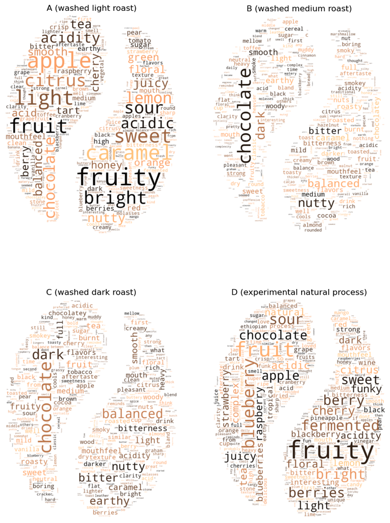

**This is great! We can see that our respondents have definitely identified characteristics we would associate with each coffee, and given us extra information about tasting notes.**

People had a wide variety of responses, but some flavours really stand out.

- **A (washed light roast Kenyan)** - this coffee is fruity and bright, people got the acidic notes of citrus, apple, berries as well as more classic nutty chocolate flavours.
- **B (washed medium roast blend)** and **C (washed dark roast blend)** - these coffees had similar responses - those classic darker roast notes of chocolate, nuts, caramel. We can see some unambiguously negative responses starting creep in as well, a few people said B and C were boring or bland.
- **D (experimental natural process)** - this coffee had more "complex", "interesting" flavours. It was very fruity, but in a different way to Coffee A, a lot of people identified a blueberry flavour. Respondents also + identified the weirder funky, fermented, alomsot wine like flavours.

This method needs a bit of tweaking to remove irrelevant words and join lemmata e.g. (all counts for "fruit" joined with those for "fruity"), but it is a great way of visualising the flavours of these coffees at a glance.

### Acidity Bitterness Matrix

Respondents were asked to rate each coffee on how **bitter** and **acidic** they were on a scale of 1 to 5.

These are defining flavour characteristics in all coffee and too much of either can be overwhelming and, frankly, disgusting:

- bitterness is associated with flavours like nuts and chocolate, bitter coffee tends to be darker roasted
- acidity is associated with flavours like citrus, green apple, or tart berries, it tends to be lighter roasted

<sub>These flavours are also highly dependent on how the coffee is brewed, but we don't have to worry about that as the samples were pre-brewed, frozen, and sent out so everyone had the same tasting experience.</sub>

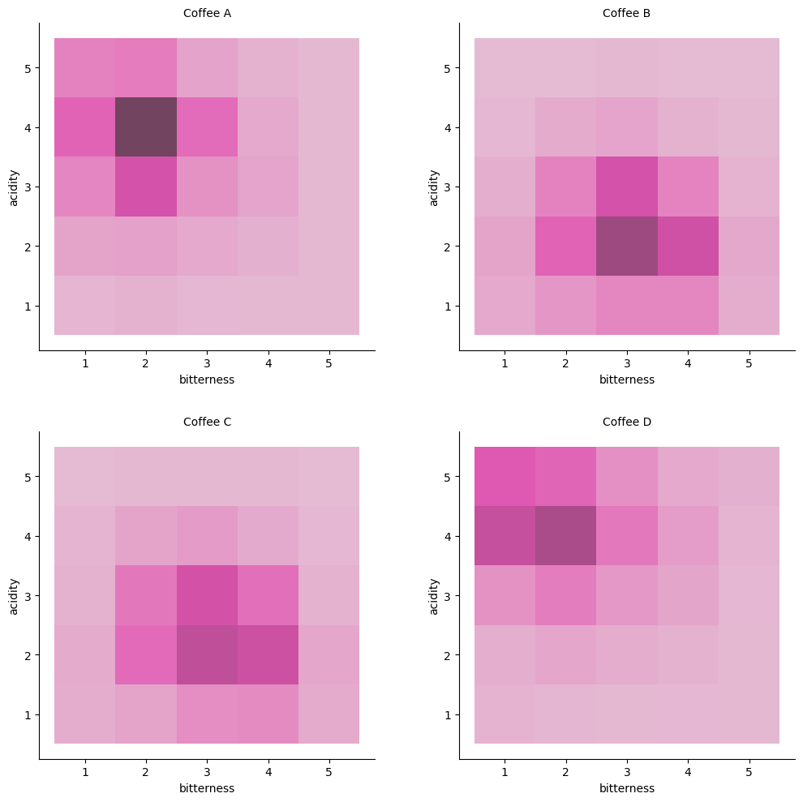

These are bivariate histograms: the darker the square the more respondents there are at those coordinates. For example, many people marked Coffee A as 2/5 bitterness, 4/5 acidic.

Coffees B and C were pretty similar, having an inoffensive but potentially boring of being low acidity and medium bitterness.

On first look, A and D are similar too having low bitterness and high acidity. When we look closer, we see that D tended a bit more acidic than A.

### Most Popular?

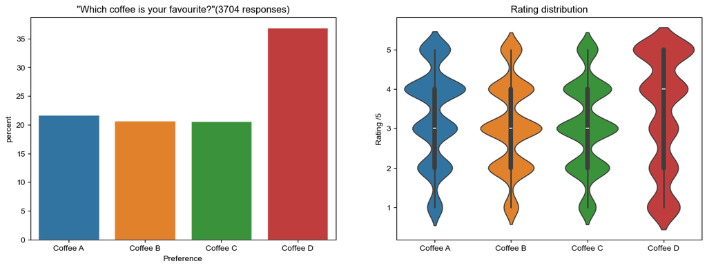

**Coffee D *appears to be* the clear winner! Hurrah for natural processed coffee.**

It is most frequently named as the favourite coffee, and it's ratings are largely higher than the others.

However, it is clearly not universally liked, otherwise it wouldn't have any low ratings. From the bulge at the bottom of the red violin plot we can see **Coffee D has the highest number of 1/5 ratings**.

Key finding: **Coffee D is the most polarizing!**

Although it has the most fans, it also has the most haters. It is marmite coffee.

If we look at the mean overall ratings, we see it is only very slightly higher than Coffee A.

|  | Mean rating /5 |
| --- | --- |
| a_rating | 3.31 |
| b_rating | 3.07 |
| c_rating | 3.06 |
| d_rating | 3.38 |

A, B, and C are more commonly given mid-range ratings, they are crowd pleasers, especially A. When we think about the types of coffee we have it makes sense:

- A, B, and C are "normal" coffees just with different levels of roast
- A is a light roast, giving those fruitier tasting notes that are clearly popular in our sample
- D is a naturally processed coffee.
  - Without getting too complicated, this imparts sweet fruity flavours, but also some fermented, "funky" flavours which some people really hate.

It will be interesting how these results are affected when we start focussing on respondents differentiated by coffee drinking habits and other factors, like age and gender.

## 2. Respondents

Back to the top

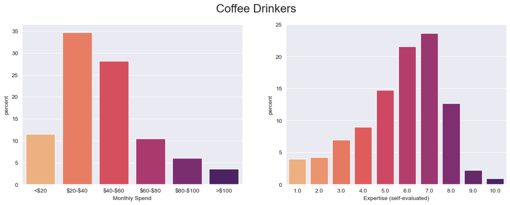

These are our respondents: most of them spend less than $60 a month on coffee and would rate their coffee expertise 5-8/10 but we have a fairly good distribution on both metrics.

Other figures calculated but not visualised: Most drink 2 cups of coffee a day, almost 60% use pourover equipment at home, and more than a third have access to an espresso machine.

Most of our respondents are clearly keener coffee consumers than the average person.

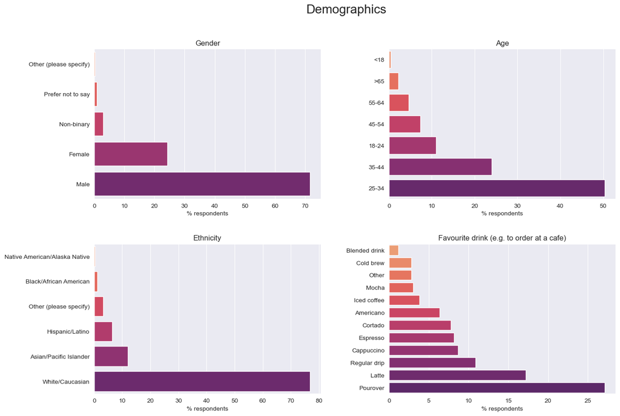

### Oh dear!

Our data set is skewed. The respondents are majority white males, mainly between the ages of 25 and 34.

There is less of a skew when it comes to favourite drink, but we should be aware of the high numbers of respondents whose favourite drink is pourover (27%). This was a surprising result in James Hoffman's opinion, and I agree. It reiterates that these respondents are not average consumers and many of them are going to have an appreciation for more experimental, complex coffees.

Let's look at how skewed demographics may have affected our conclusions about the most popular coffee, beginning with gender.

## 3. Gender

Back to the top

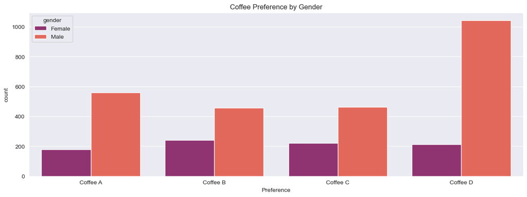

### Men like coffees A and D, female preference is far more evenly distributed.

Our initial conclusion that A and D were the most popular coffees may have been misguided, the data has been totally skewed by the number of men and their preferences. Coffee B is very narrowly the favourite amongst women.

Let's take a closer look at the distribution of overall ratings given for each coffee by men and women.

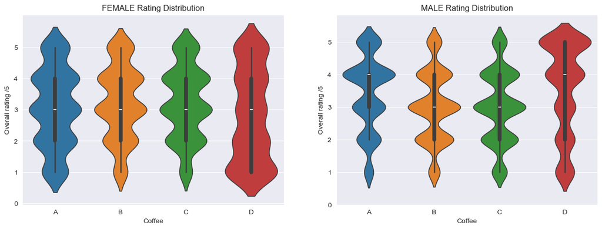

### Women hate coffee D more than they love it. Men really like it.

Look at the red violin plots, they show the density of ratings at each level and have a box-and-whisker plot at their heart showing the median and quartiles.

It is important to note that women also rated Coffee D 5/5 more frequently than any other coffee, reiterating it's polarising nature. Coffees A, B, and C were far safer bets, women are unlikely to hate them, but unlikely to love them either.

## 4. Age

Back to the top

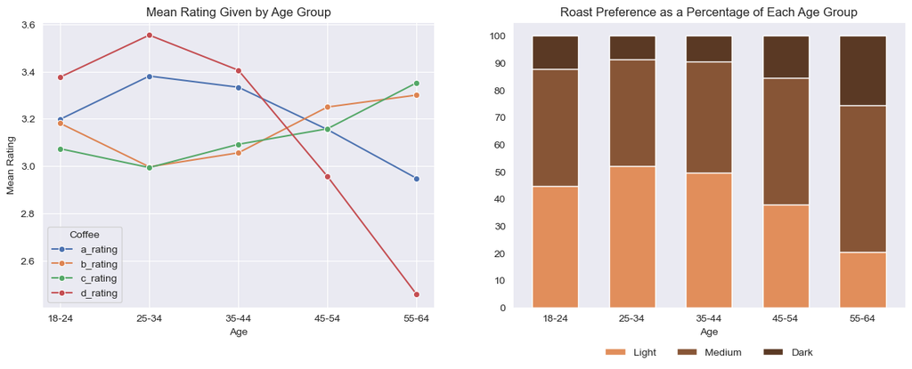

### Coffees A and D decline in overall rating as respondents age, while Coffees B and C increase.

This makes sense, especially when we look at the proportion of roast preferences in the different age groups. As respondents get older appreciation of light roasts diminishes.

Older respondents react positively to more traditional, "normal" tasting coffee, reflecting their increased appetite for darker roasts.

### Again the data is being skewed by one particular group: younger people.

Respondents aged between 25 and 44 rate coffees A and D highly, and they represent over 75% of respondents. Older consumers are far less likely to enjoy coffee D, but their opinion is not represented unless we look at the results by age.

## 5. Ethnicity

Back to the top

**There is no significant relationship between ethnic background and coffee preference.**

White respondents preferred Coffee D more often than other respondents but their preferences were not significantly different from Hispanic/Latino and Asian/Pacific Islanders. Together these 3 groups represent ~95% of respondents.

Looking at the chart on the left, one might argue that these groups skew the data because Black/African American respondents preferred C. But, in reality, it is irresponsible to infer preference based on ethnicity from such a small sample (there were only 39 respondents (~1%) who were Black/African American).

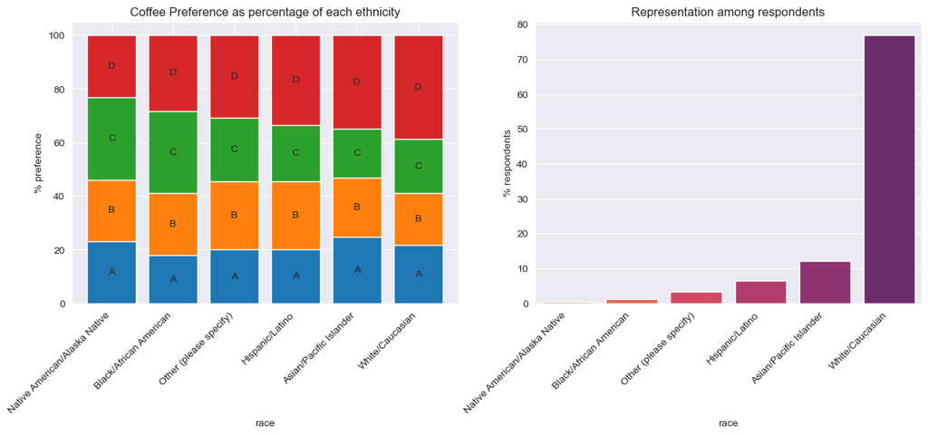

## 6. Favourite Type of Drink

Back to the top

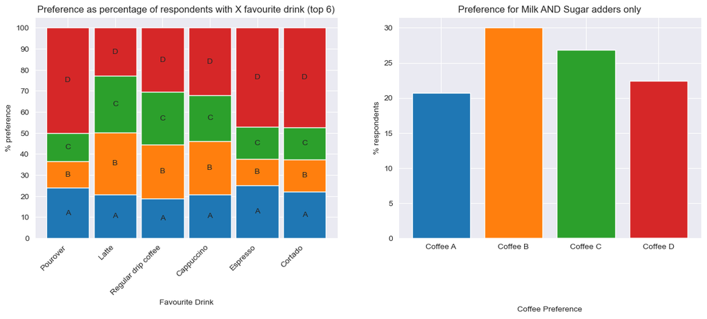

### People who like less coffee flavour in their drink like coffees B and C more

People who like Espresso, Cortado, and Pour-overs are more likely to like coffee D. These drinks all tend to have more intense flavours. While latte and cappucino are heavily diluted by milk, espresso and cortado have no/little milk. Pour-over and regular drip are similar concepts, but pourover extracts more flavours (longer extraction time) without overextracting (lower temperature normally), resulting in the consumer getting a more flavourful coffee.

This is further evidenced by the fact that respondents who would normally add milk and sugar to coffee liked coffees B and C more.

It seems that the people who don't like a strong coffee flavour to their coffee prefer coffees B and C, while those who like pour-over or low milk drinks, appreciate coffees A and D more.

## 7. Spenders

Back to the top

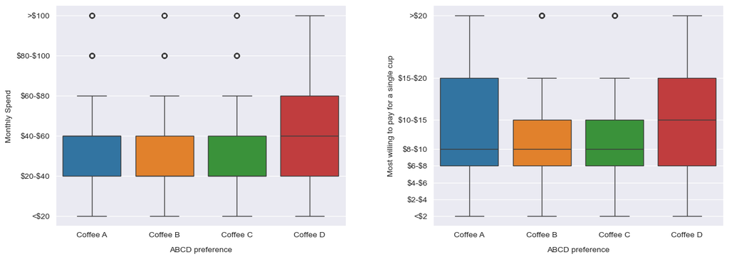

### There are outliers in every group, but it is clear that Coffee D lovers spend more money

There are small but significant numbers of Coffee D lovers spending more than \$100 a month on coffee, and the median amount of money they would be willing to spend on a single cup is \$10-15! Significant numbers of A and D lovers would spend >$20 on a cup of coffee.

## 8. Experts?

Back to the top

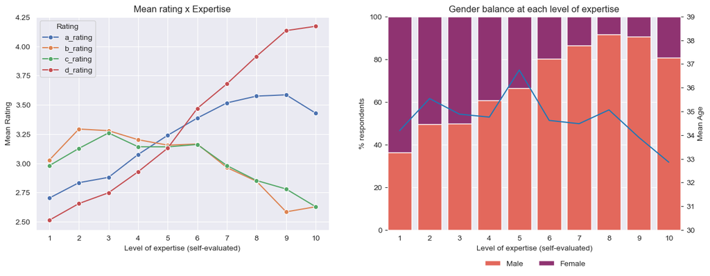

### Expertise has a positive correlation with the appreciation for Coffee D

"Experts" also rated Coffee A relatively highly.

**BUT**, we can see that those who rated themselves experts were overwhelmingly male and tended to be younger. This does not automatically invalidate the expert opinion, but it does mean that the we don't really know what female experts or older experts think about this coffee.

From the very small sample we have, we can see that female experts agree that Coffee D is the best but by a much smaller margin.

```
Mean Ratings by Respondents rating their expertise >= 9/10
```

| gender | a_rating | b_rating | c_rating | d_rating | count |
| --- | --- | --- | --- | --- | --- |
| Female | 3.2 | 2.8 | 2.8 | 3.5 | 13 |
| Male | 3.6 | 2.6 | 2.8 | 4.2 | 92 |

### Other information on expert coffee habits

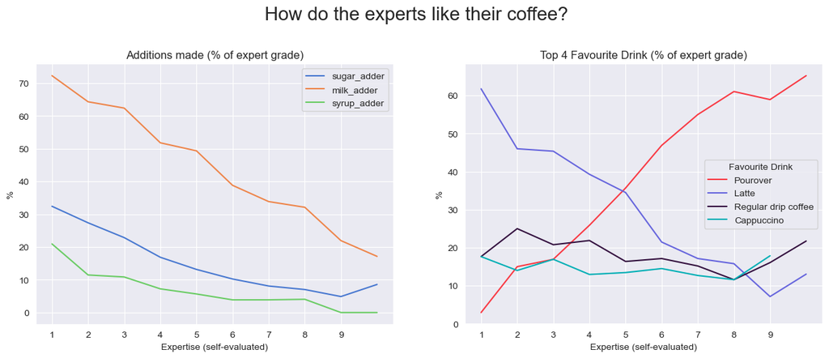

### Experts like their coffee unadulterated.

The percentage of respondents adding anything to their coffee declines as expertise increases. Unsurprisingly, the percentage of people who drink pour-overs increases; pourover is frequently enjoyed as a form of coffee unadulterated by milk or any other flavouring.

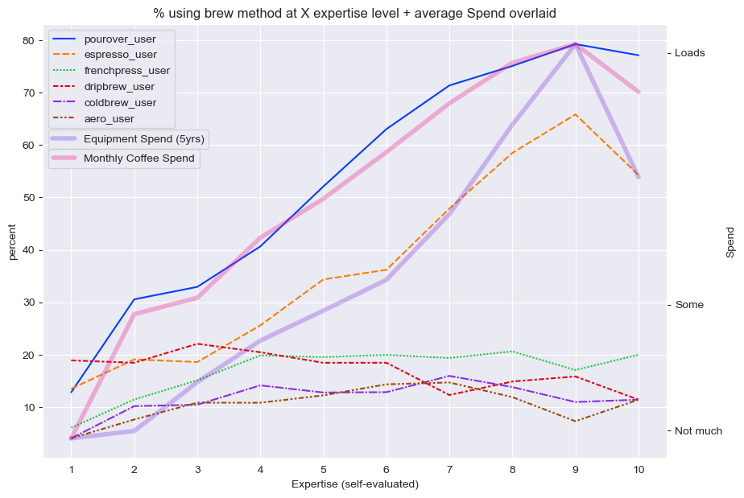

### Most experts use espresso machines and pour-overs.

Inevitably this leads to higher equipment costs. But interestingly the more you spend on equipment, the more you spend on coffee in general i.e. investing in the ability to make coffee at home does not save money (I probably could have told you this from experience tbh).

There is a tight correlation between pour-over users and monthly spend, these are likely the same group who buy pour-overs at a cafe (expensive) and may well buy beans to use at home.

The correlation between espresso machine users and equipment spend is upsetting but inevitable.

## Conclusion

We started with an analysis of the flavour profiles of each coffee before discovering that Coffee D is the most popular.

When we reviewed our respondents we found that our data was skewed in favour of young white males and we had a lot of pour-over fans as well. Analysis showed that these groups are the driving force behind Coffee D's high rating.

**However**, the analysis of expert opinion raised the question: **is it young men skewing the sample? Or is it "experts", the vast majority of whom happen to be young and male?**

Below, we analyse correlation between overall rating and other numerical data.

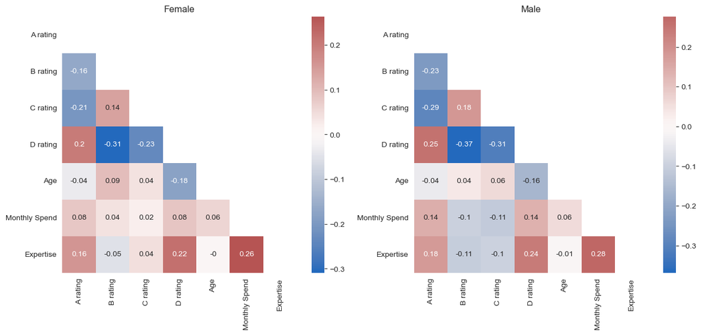

**While there are no particularly strong correlations (near +/- 1), any stronger than +/- 0.2 are significant for our purposes.**

We can see that for both men and women there was some positive correlation between A and D ratings, and negative correlation between D ratings and B/C ratings. **If you like Coffee D, you are unlikely to like Coffee B, but you might like Coffee A.**

While ratings correlate minimally with age or spend, **the strongest predictor of a high D rating is level of expertise**. There is also high correlation between spending and expertise.

**So, it is too simplistic to say that men like this coffee and women don't, because there is a similar pattern of correlation in both female and male respondents.** There are simply far more male respondents and their expertise is skewed higher. It is these experts skewing the results in favour of Coffee D.

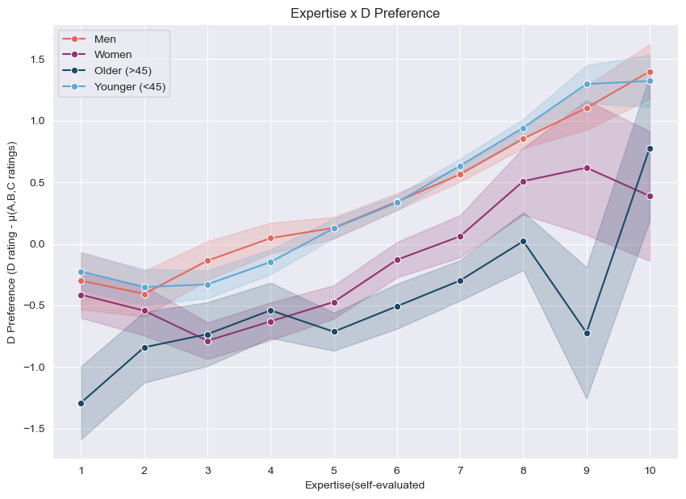

**Where we have the most data we can see the smoothest trend towards higher expertise == higher D rating**

This plot shows the relationship between expertise (x) and preference for coffee D (y) (calculated as *D rating - µ(A, B,C ratings)* among 4 different demographic groups.

The shaded areas show the standard error, you can see the margin of error is larger for the demographics where we have fewer respondents. We can see a lot of uncertainty around female expert opinion because very few female respondents marked themselves as highly expert.

**For Male respondents and younger respondents** (groups where we have the most data), there is a clear correlation between expertise and Coffee D rating. Respondents with less knowledge rate it below average but "experts" end up rating it ~1.3 above average.

**Female respondents** rate coffee D below average until their expertise level reaches 7 after which they rate it above average. But there is so much uncertainty (because of the small numbers of female respondents) that the correlation is less reliable. The female expert preference for Coffee D is more marginal and uncertain.

Uncertainty is high for **older respondents** but they do not exhibit high levels of preference for Coffee D. There is also a weak but noticeable negative correlation between age and Coffee D rating. We can say with more certaintly that older respondents do not like Coffee D in most cases.

## Recommendations

If I was recommending which of these coffees a cafe should offer, I would still definitely say D should be on the menu.

It may be polarising, and unpopular among customers with less coffee experience, but it is interesting and something high-spending coffee connoisseurs will spend money on. Coffee D is best offered as a pour over, the favourite drink format of most of the people who like it.

But the cafe will still need a coffee for its espresso based drinks (latte, cappucino, flat white etc.), it could be Coffee B or C. I would recommend B, it is slightly more popular among women, latte/cappucino drinkers, and a few other groups. People who do not like D are likely to enjoy B.

With just these 2 coffees on the menu a cafe would have all their bases covered.